# Project 3

Qinzhi Peng

Fall 2022

## Exploratory Data Anaylsis

### Basic Information

#### Observations

First, We can see a few observations below. It seems that there is no obviously non-informative column.

```r
# see a few observations
head(df)
```

```
##   fix.acid vol.acid citric sugar chlorides free.sd total.sd density   pH
## 1      6.9    0.190   0.32   7.9     0.042      30    130.0       2 3.40
## 2      7.6    0.200   0.30  14.2     0.056      53    212.5       2 3.14
## 3     10.4    0.380   0.46   2.1     0.104       6     10.0       2 3.12
## 4      6.8    0.350   0.32   2.4     0.048      35    103.0       2 3.28
## 5     11.4    0.625   0.66   6.2     0.088       6     24.0       2 3.11
## 6      6.5    0.290   0.25   2.5     0.142       8    111.0       2 3.00
##   sulphates alcohol label
## 1      0.39    10.5  GOOD
## 2      0.46     8.9  GOOD
## 3      0.65    11.8  GOOD
## 4      0.46    12.0  GOOD
## 5      0.99    13.3  GOOD
## 6      0.44     9.9   BAD
```

#### Data Description

Get some basic information for this new data set.

```r
str(df)
```

```
## 'data.frame':    6497 obs. of  12 variables:
##  $ fix.acid : num  6.9 7.6 10.4 6.8 11.4 6.5 6.1 9.5 7.6 6.7 ...
##  $ vol.acid : num  0.19 0.2 0.38 0.35 0.625 0.29 0.26 0.885 0.16 0.42 ...
##  $ citric   : num  0.32 0.3 0.46 0.32 0.66 0.25 0.51 0.27 0.44 0.39 ...
##  $ sugar    : num  7.9 14.2 2.1 2.4 6.2 2.5 2.2 2.3 1.4 12.1 ...
##  $ chlorides: num  0.042 0.056 0.104 0.048 0.088 0.142 0.05 0.084 0.043 0.04 ...
##  $ free.sd  : num  30 53 6 35 6 8 61 31 25 61 ...
##  $ total.sd : num  130 212 10 103 24 ...
##  $ density  : int  2 2 2 2 2 2 2 2 2 2 ...
##  $ pH       : num  3.4 3.14 3.12 3.28 3.11 3 3.08 3.24 3.11 3.31 ...
##  $ sulphates: num  0.39 0.46 0.65 0.46 0.99 0.44 0.6 0.53 0.75 0.58 ...
##  $ alcohol  : num  10.5 8.9 11.8 12 13.3 9.9 9.8 9.4 10.3 9.7 ...
##  $ label    : Factor w/ 2 levels "BAD","GOOD": 2 2 2 2 2 1 2 1 2 1 ...
```

There are 6497 rows and 12 columns in the data set. It contains 11 predictor variables - all are quantitative, and a response variable that is `label`.

### Data Distributions

#### Response variable

Show distributions of the response variable `label`.

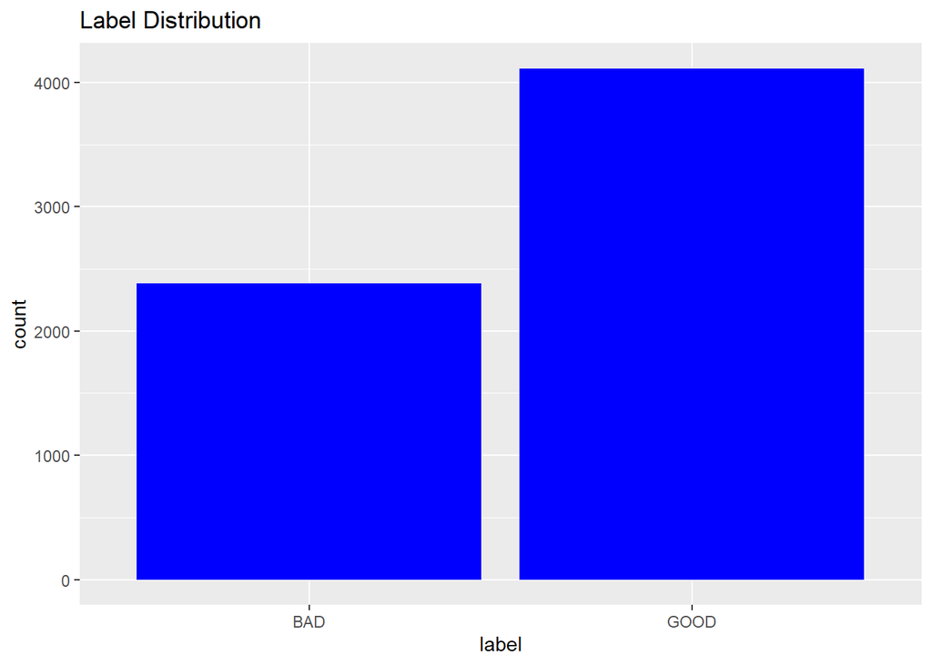

```r
ggplot(data = df, mapping=aes(x = label)) +
  geom_bar(fill="blue") +
  ggtitle("Label Distribution")
```

We can see that two classes are unbalanced, so we should not assume a class-separation threshold of 0.5.

#### Predictor Variables

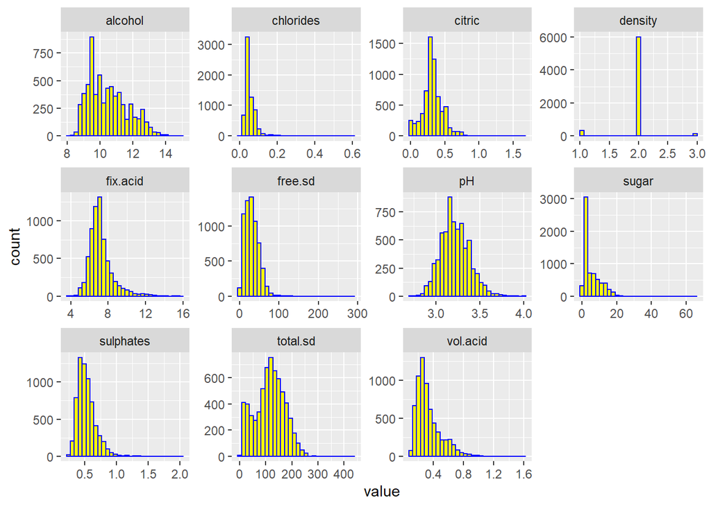

```r
df.qnt <- df %>%
  dplyr::select(-label) %>%
  gather()

#  visualize the data in multiple columns, side by side
ggplot(data = df.qnt, mapping = aes(x = value)) +
  geom_histogram(color = "blue", fill = "yellow", bins = 30) +
  facet_wrap(~ key, scales = 'free')
```

We can see there are a few variables are highly right-skewed, like `free.sd`, `sugar`. So we will do the transformation for these variables.

#### response vs. predictor variables

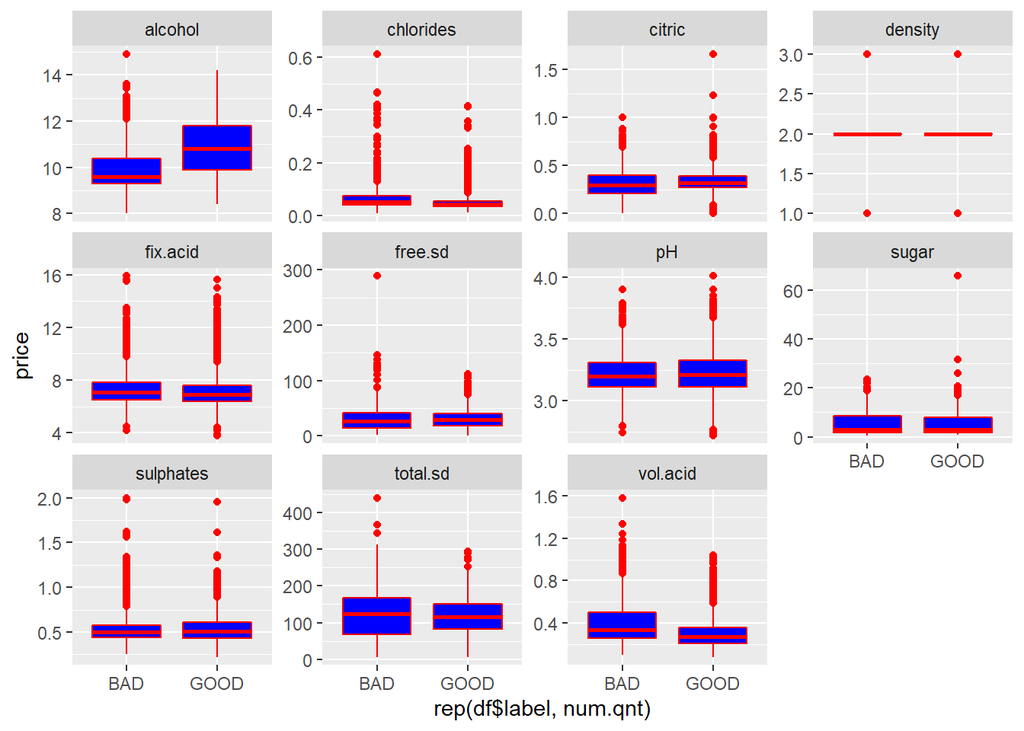

```r
num.qnt <- 11

ggplot(data = df.qnt, mapping = aes(x = rep(df$label, num.qnt), y = value)) +
  geom_boxplot(color="red", fill="blue") +
  facet_wrap(~ key, scales = 'free_y') +
  ylab("price")
```

We can see there are some clear associations between the `label` and predictor variables. For example, with a great percentage of alcohol, the `label` is more likely to be GOOD. That implies we can produce some statistical model to predict `label` with these variables.

### Data Processing

#### Summary

Get a textual summary of the data set and it seems that there are no missed values or weird values in the data set.

```r
summary(df)
```

```
##     fix.acid         vol.acid          citric           sugar
##  Min.   : 3.800   Min.   :0.0800   Min.   :0.0000   Min.   : 0.600
##  1st Qu.: 6.400   1st Qu.:0.2300   1st Qu.:0.2500   1st Qu.: 1.800
##  Median : 7.000   Median :0.2900   Median :0.3100   Median : 3.000
##  Mean   : 7.215   Mean   :0.3397   Mean   :0.3186   Mean   : 5.443
##  3rd Qu.: 7.700   3rd Qu.:0.4000   3rd Qu.:0.3900   3rd Qu.: 8.100
##  Max.   :15.900   Max.   :1.5800   Max.   :1.6600   Max.   :65.800
##    chlorides          free.sd          total.sd        density
##  Min.   :0.00900   Min.   :  1.00   Min.   :  6.0   Min.   :1.00
##  1st Qu.:0.03800   1st Qu.: 17.00   1st Qu.: 77.0   1st Qu.:2.00
##  Median :0.04700   Median : 29.00   Median :118.0   Median :2.00
##  Mean   :0.05603   Mean   : 30.53   Mean   :115.7   Mean   :1.97
##  3rd Qu.:0.06500   3rd Qu.: 41.00   3rd Qu.:156.0   3rd Qu.:2.00
##  Max.   :0.61100   Max.   :289.00   Max.   :440.0   Max.   :3.00
##        pH          sulphates         alcohol       label
##  Min.   :2.720   Min.   :0.2200   Min.   : 8.00   BAD :2384
##  1st Qu.:3.110   1st Qu.:0.4300   1st Qu.: 9.50   GOOD:4113
##  Median :3.210   Median :0.5100   Median :10.30
##  Mean   :3.219   Mean   :0.5313   Mean   :10.49
##  3rd Qu.:3.320   3rd Qu.:0.6000   3rd Qu.:11.30
##  Max.   :4.010   Max.   :2.0000   Max.   :14.90
```

#### Data Transformation

Do the log transformation for highly skewed variables.

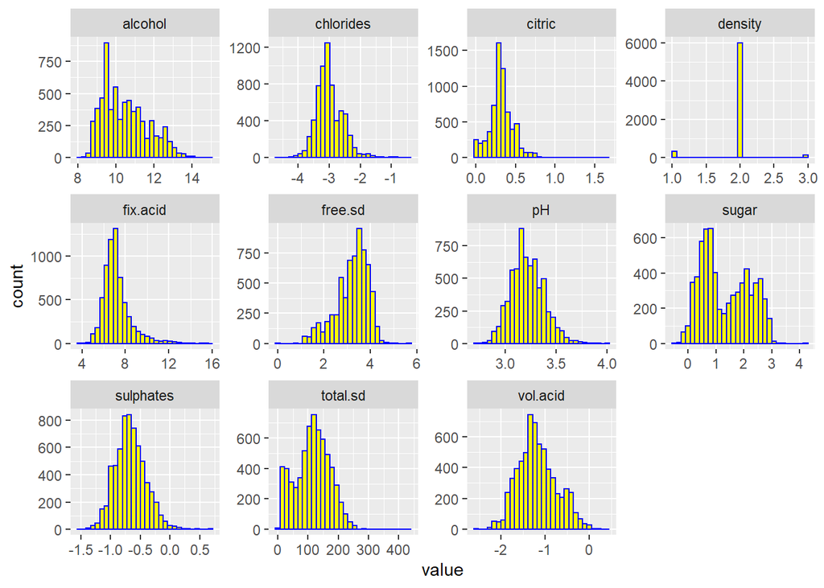

```r
# define a new data set for the log transformation
df.log <- df
df.log$vol.acid = log(df.log$vol.acid)
df.log$chlorides = log(df.log$chlorides)
df.log$free.sd = log(df.log$free.sd)
df.log$sulphates = log(df.log$sulphates)
df.log$sugar = log(df.log$sugar)

df.qnt.log <- df.log %>%
  dplyr::select(-label) %>%
  gather()

#  visualize the data in multiple columns, side by side
ggplot(data = df.qnt.log, mapping = aes(x = value)) +
  geom_histogram(color = "blue", fill = "yellow", bins = 30) +
  facet_wrap(~ key, scales = 'free')
```

#### Removing Outliers

As we can see in the figures, there are some obvious outliers in the data set.

```r
df.new <- df.log
# examine outliers
df[which(df.log$citric > 1),]
```

```
##      fix.acid vol.acid citric sugar chlorides free.sd total.sd density   pH
## 74        7.4     0.20   1.66   2.1     0.022      34      113       2 3.26
## 5471      7.6     0.25   1.23   4.6     0.035      51      294       2 3.03
##      sulphates alcohol label
## 74        0.55    12.2  GOOD
## 5471      0.43    13.1  GOOD
```

```r
df[which(df.log$total.sd > 350),]
```

```
##      fix.acid vol.acid citric sugar chlorides free.sd total.sd density   pH
## 4101      8.6     0.55   0.35 15.55     0.057    35.5    366.5       3 3.04
## 4321      6.1     0.26   0.25  2.90     0.047   289.0    440.0       2 3.44
##      sulphates alcohol label
## 4101      0.63    11.0   BAD
## 4321      0.64    10.5   BAD
```

```r
# define the indexes of outliers
index.outiers <-  which(df.log$citric > 1 | df.log$total.sd > 350)

# define new data set
df.new <- df.log[-index.outiers,]
```

These outliers have really large `citric` and `total.sd` values, we think these observations maybe are some special cases. Then, we remove all these outliers before training our model.

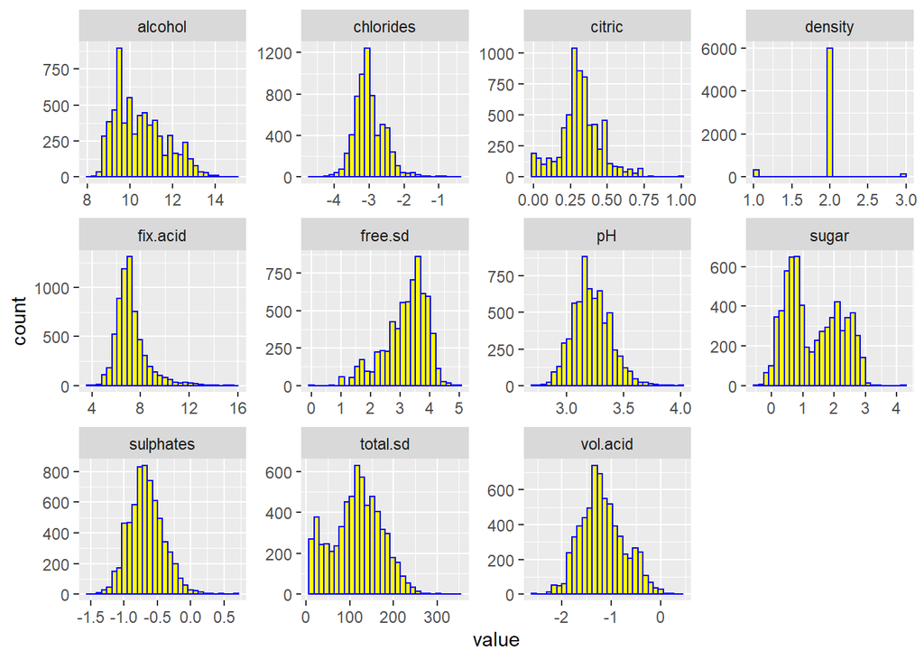

```r
# visualize the data after the data processing
df.qnt.new <- df.new %>%
  dplyr::select(-label) %>%
  gather()

ggplot(data = df.qnt.new, mapping = aes(x = value)) +
  geom_histogram(color = "blue", fill = "yellow", bins = 30) +
  facet_wrap(~ key, scales = 'free')
```

After the log transformation and the removal of outliers, we can see that the distributions predictors appear to not be highly skewed.

### Correlation

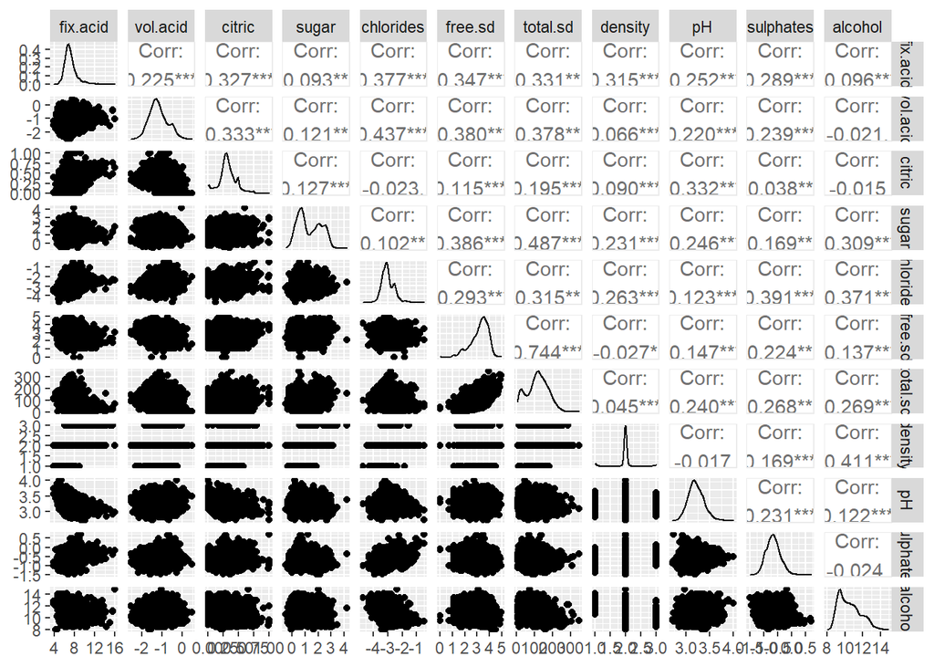

```r
df.new %>%
  dplyr::select(-label) %>%
  ggpairs(lower = list(combo = wrap("facethist", binwidth = 0.8)), progress=FALSE)
```

We can clearly see the correlation coefficients between the `total.sd` and `free.sd` is all greater than 0.7, which means they are correlated. Since our goal is prediction, the multicollinearity is acceptable in this case.

## Model Selection

### Split the data

Split the data into training and test sets in a 70%-30% ratio.

```r
# split the response and predictors
response   <- df.new[,12]
predictors <- data.frame(scale(df.new[,-12]))

# split training and test
set.seed(100)
s <- sample(nrow(df.new), round(0.7*nrow(df.new)))
pred.train <- predictors[s,]
pred.test <- predictors[-s,]
resp.train <- response[s]
resp.test <- response[-s]
df.train <- cbind(pred.train,resp.train)
df.test <- cbind(pred.test,resp.test)
```

### Logistic Regression

First, we do the Logistic Regression between response and predictor variables. Also, we output Class 1 probabilities and record its ROC result.

```r
out.glm = glm(resp.train ~ ., data = pred.train, family = binomial)
# extract Class 1 probabilities
resp.prob.glm = predict(out.glm, newdata = pred.test, type = "response")
# output a few of probabilities
resp.prob.glm[1:10]
```

```
##          3          5          8         11         13         15         22
## 0.84642964 0.95350476 0.09841495 0.94139398 0.57773566 0.37211447 0.20475757
##         24         43         46
## 0.65744030 0.18838022 0.94536820
```

```r
roc.glm = roc(resp.test, resp.prob.glm)
```

Meanwhile, we perform the Best-subset-selection for Logistic model, and use the best model to get Class 1 probabilities.

```r
# expect the response variable to be named y
y <- df.train$resp.train
df.train.bestglm <- df.train[,-12]
df.train.bestglm <- data.frame(df.train.bestglm,"y"=y)
y <- df.test$resp.test
df.test.bestglm <- df.test[,-12]
df.test.bestglm <- data.frame(df.test.bestglm,"y"=y)

# variable selection
out.aic <- bestglm(df.train.bestglm, family = binomial, IC = "AIC")
out.aic$BestModel
```

```
##
## Call:  glm(formula = y ~ ., family = family, data = Xi, weights = weights)
##
## Coefficients:
## (Intercept)     vol.acid       citric        sugar      free.sd     total.sd
##     0.79100     -0.75201     -0.06046      0.37228      0.45089     -0.54738
##     density    sulphates      alcohol
##    -0.13582      0.35701      1.05876
##
## Degrees of Freedom: 4544 Total (i.e. Null);  4536 Residual
## Null Deviance:       5940
## Residual Deviance: 4627  AIC: 4645
```

```r
# get class 1 prob
resp.prob.bestglm = predict(out.aic$BestModel, newdata = df.test.bestglm, type = "response")
```

```r
resp.prob.bestglm[1:10]
```

```
##          3          5          8         11         13         15         22
## 0.84533289 0.95297084 0.09133012 0.94028436 0.56682520 0.37322620 0.20062960
##         24         43         46
## 0.63450726 0.19250800 0.94780878
```

```r
roc.bestglm = roc(resp.test, resp.prob.bestglm)
```

### Classification Trees

```r
out.rpart = rpart(resp.train ~ .,data = pred.train)
# extract Class 1 probabilities
resp.prob.rpart = predict(out.rpart, newdata = pred.test, type="prob")[,2]
resp.prob.rpart[1:10]
```

```
##         3         5         8        11        13        15        22        24
## 0.7964998 0.7964998 0.3288390 0.7964998 0.6814921 0.3288390 0.3288390 0.6814921
##        43        46
## 0.3288390 0.7964998
```

```r
roc.rpart = roc(resp.test, resp.prob.rpart)
```

### Random Forest

```r
out.rf = randomForest(resp.train ~ ., data = pred.train, importance=TRUE)
# extract Class 1 probabilities
resp.prob.rf = predict(out.rf, newdata = pred.test, type="prob")[,2]
resp.prob.rf[1:10]
```

```
##     3     5     8    11    13    15    22    24    43    46
## 0.942 0.856 0.042 0.964 0.590 0.452 0.094 0.710 0.282 0.982
```

```r
roc.rf = roc(resp.test, resp.prob.rf)
```

### KNN

For the KNN model, we need to first choose the best `k` value.

```r
k.max = 30
mcr.k = rep(NA,k.max)
for ( kk in 1:k.max ) {
  knn.cv = knn.cv(train = pred.train, cl = resp.train, k = kk)
  mcr.k[kk] = mean(knn.cv!=resp.train)
}
k.min = which.min(mcr.k)
cat("The optimal number of nearest neighbors is ",k.min,"\n")
```

```
## The optimal number of nearest neighbors is  1
```

Plot the validation-set MCR versus k.

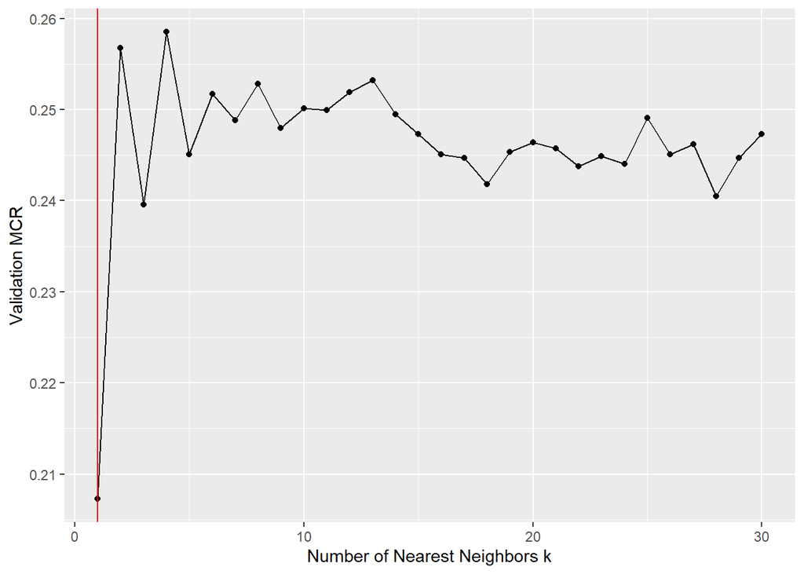

```r
# plot the validation-set MCR versus k
ggplot(data=data.frame("k"=1:k.max, "mcr"=mcr.k), mapping=aes(x=k, y=mcr)) +
  geom_point() + geom_line() +
  xlab("Number of Nearest Neighbors k") + ylab("Validation MCR") +
  geom_vline(xintercept=k.min,color="red")
```

```r
out.knn = knn(train = pred.train, test = pred.test, cl = resp.train, k = k.min, algorithm="brute", prob=TRUE)
# get class 1 probabilities
resp.prob.knn = attributes(out.knn)$prob
w = which(out.knn=="BAD")
resp.prob.knn[w] = 1 - resp.prob.knn[w]
# output a few probs
resp.prob.knn[1:10]
```

```
##  [1] 1 1 0 1 1 0 0 1 0 1
```

```r
roc.knn = roc(resp.test, resp.prob.knn)
```

### SVM

For the SVM model, it will take a long time to determine an optimal `cost` value. Thus, We just assume `cost = 1` here, which might not be optimal but save time. We also try both linear and polynomial kernels in the SVM models.

```r
# linear kernel
out.svm.linear  = tune(svm, resp.train ~ . , data = df.train, kernel="linear", ranges=list(cost=1), prob = TRUE)
resp.pred.svm.linear = predict(out.svm.linear$best.model, newdata=df.test, prob = TRUE)
resp.prob.svm.linear = attributes(resp.pred.svm.linear)$prob[, 1]
# show a few probs
resp.prob.svm.linear[1:10]
```

```
##          3          5          8         11         13         15         22
## 0.83409080 0.93848636 0.08973702 0.93124500 0.62034664 0.36658729 0.18593161
##         24         43         46
## 0.72750432 0.19457600 0.93649397
```

```r
# polynomial kernel
out.svm.poly = tune(svm, resp.train ~ ., data = df.train, kernel="polynomial", ranges=list(cost=1, degree=2:4), prob = TRUE)
resp.pred.svm.poly = predict(out.svm.poly$best.model, newdata=df.test, prob = TRUE)
resp.prob.svm.poly = attributes(resp.pred.svm.poly)$prob[, 1]
# show a few probs
resp.prob.svm.poly[1:10]
```

```
##          3          5          8         11         13         15         22
## 0.88418631 0.98392181 0.02350084 0.80026597 0.63666270 0.66927209 0.25394557
##         24         43         46
## 0.65063002 0.19545436 0.86569047
```

```r
roc.svm.linear = roc(resp.test, resp.prob.svm.linear)
roc.svm.ploy = roc(resp.test, resp.prob.svm.poly)
```

### ROC curves & AUC

Plot and compare ROC curves for different model, and output their AUC values.

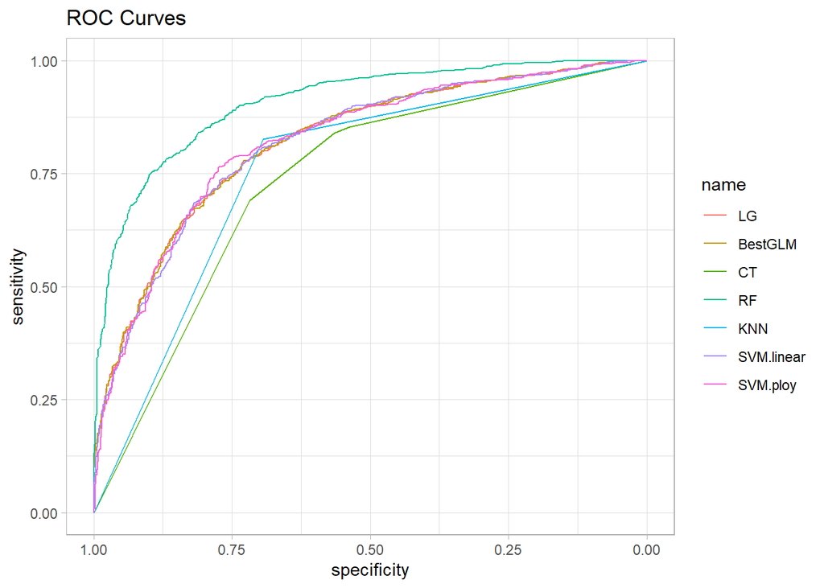

```r
ggroc(list(LG = roc.glm, BestGLM = roc.bestglm, CT = roc.rpart, RF = roc.rf, KNN = roc.knn, SVM.linear = roc.svm.linear, SVM.ploy = roc.svm.ploy),) + theme_light() + ggtitle("ROC Curves")
```

```r
knitr::kable(data.frame(roc.glm$auc, roc.bestglm$auc, roc.rpart$auc, roc.rf$auc, roc.knn$auc, roc.svm.linear$auc, roc.svm.ploy$auc))
```

| roc.glm.auc | roc.bestglm.auc | roc.rpart.auc | roc.rf.auc | roc.knn.auc | roc.svm.linear.auc | roc.svm.ploy.auc |
| --- | --- | --- | --- | --- | --- | --- |
| 0.820893 | 0.8210469 | 0.7357652 | 0.9077351 | 0.7601137 | 0.819265 | 0.8208238 |

We can see clearly that the Random Forest model has the highest AUC value. So we use this model to make class predictions.

## Prediction

### class-separation Threshold

Use Youden’s J statistic to determine the optimal class-separation threshold. We assume that sensitivity and specificity are equally important.

```r
# find the threshold associated with that maximum value
optimal.idx <- which.max(roc.rf$sensitivities + roc.rf$specificities - 1)
# the optimal class-separation threshold
threshold <- roc.rf$thresholds[optimal.idx]
threshold
```

```
## [1] 0.647
```

### Confusion Matrix

```r
# class predictions
resp.pred.rf <- as.factor(ifelse(resp.prob.rf > threshold, "GOOD", "BAD"))
# create a confusion matrix
tab.rf <- table(resp.pred.rf, resp.test)
tab.rf
```

```
##             resp.test
## resp.pred.rf BAD GOOD
##         BAD  647  261
##         GOOD  98  942
```

From the confusion matrix, we can see we will get more false negatives than false positives in the prediction.

### Misclassification rate

```r
misrate.test <- 1-sum(diag(tab.rf))/sum(tab.rf)
misrate.test
```

```
## [1] 0.1842916
```

The misclassification rate is 0.18. That means our model is good for predictions and also has relatively high sensitivity and specificity.